# python 基础 和 模块简介

在本章中，我们将讨论基本概念和几种广泛使用的功能 本章只是专门基于Python技术的章节。 那两个 本章是对具有一些Python基本知识的回顾。 没有任何Python知识的初学者无法只需阅读这两章即可了解掌握Python。 对于想学习的新学习者 更详细地了解Python，他/她可以找到许多不错的书。 从第3章开始，我们将使用Python，这将有助于解释或 演示各种财务概念，进行回归并处理数据（与经济学，金融学和会计学）有关。 因此在接下来的每一章中，都将介绍与Python有关的技术和用法。

在本章中，我们将讨论以下主题：

- Python安装
- 变量，和编写我们自己的程序
- 编写Python函数
- 数据输入
- 数据处理
- 数据输出

## python 安装

推荐大家使用annaconda 安装，因为对于初学者来说，在win下会遇到环境变量问题，以及版本数据包的问题，mac中会遇到与其他IDE的融合问题比如pycharm，当然如果你喜欢探索，或者已经很了解python 和你的应用系统，那么选择自己的喜好就可以。https://www.anaconda.com/products/individual 选择自己的系统，下载安装。

安装完成后，打开anaconda navigator

[figure not shown]

常用的是spyder jupyter-notebook pycharm，对于我们目前的任务，推荐使用jupyter，因为可以写文字加代码和图片结果展示，很适合学习

假设我们今天将100美元存入银行。 3年后的价值是多少？假设银行向我们提供1.5％的年存款利率？

相关代码如下所示：

```python
pv=100
v_3years=pv*(1+0.015)**3
print(v_3years)
```

```
104.56783749999997
```

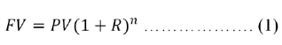

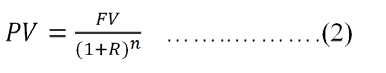

假设我们今天投资100美元，明年投资30美元，那么从第二年年底开始的未来5年，每年年底的未来现金流入将分别为10美元，40美元，50美元，45美元和20美元：

```python
cash_flows=[-100,-30,10,40,50,45,20]
def npv_f (rate,cash_flows):
    total=0.0
    for i,s in enumerate(cash_flows):
        total+=s/(1+rate)**i
    return total

print(npv_f(0.05,cash_flows))

x=["a","b","z"]
for i, value in enumerate(x):
    print(i,value)
```

```
6.370479317818267
0 a
1 b
2 z
```

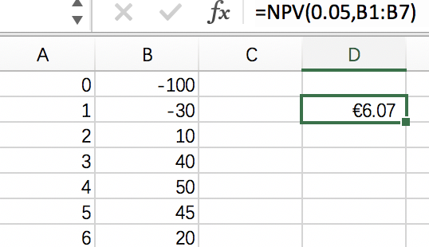

```python
def npv_excel (rate,cash_flows):
    total=0.0
    for i,s in enumerate(cash_flows):
        total+=s/(1+rate)**(i+1)
    return total
print(npv_excel(0.05,cash_flows))
```

```
6.067123159826915
```

## data input

```python
import pandas as pd
url='http://canisius.edu/~yany/data/ibm.csv'
path=url='/...../~yany/data/ibm.csv'
# data=pd.read_csv(url)
# data=pd.read_csv(path)
# data=pd.read_pickle(path)
```

[output not shown]

```python
grade=74
if grade>=90:
    print('A')
elif grade >=85:
    print('A-')
elif grade >=80:
    print('B+')
elif grade >=75:
    print('B')
elif grade >=70:
    print('B-')
elif grade>=65:
    print('C+')
else:
    print('D')
```

```
B-
```

## 模块简介

我们接下来介绍一些跟我们金融方向比较重要的模块，插入模块可以使用import关键字，as后边是我们想用的建成，也可以from 模块 import a，b，c 但我认为应该避免这么使用

比如我们可以用这些模块编写一个bs看涨期权模型

```python
import sys as s
import time as tt
import numpy as np
import matplotlib as mp
from scipy import log,exp,sqrt,stats
def bsCall(S,X,T,r,sigma):
    from scipy import log,exp,sqrt,stats
    d1=(log(S/X)+(r+sigma*sigma/2.)*T)/(sigma*sqrt(T))
    d2 = d1-sigma*sqrt(T)
    return S*stats.norm.cdf(d1)-X*exp(-r*T)*stats.norm.cdf(d2)
```

### Introduction to NumPy

```python
import numpy as np
```

```python
x=np.array([[1,2,3],
            [4,5,6]])#2*3矩阵
```

```python
np.size(x)#元素数目
```

```
6
```

```python
print(x)
```

```
[[1 2 3]
 [4 5 6]]
```

```python
print('x:row',np.size(x,0))
print('x:col',np.size(x,1))
```

```
x:row 2
x:col 3
```

```python
np.std(x)
```

```
1.707825127659933
```

```python
np.std(x,1)
```

```
array([0.81649658, 0.81649658])
```

```python
np.std(x,0)
```

```
array([1.5, 1.5, 1.5])
```

```python
x.sum()
```

```
21
```

```python
np.random.rand(5)#from0 to 1
```

```
array([0.73848436, 0.41280829, 0.20572844, 0.63462117, 0.91739086])
```

```python
np.random.normal(size=10)
```

```
array([ 0.53855935,  0.65561991, -0.62924326, -0.52600809,  0.00915957,
        1.35802665, -0.77315119,  1.14134898,  1.0521077 , -1.47873156])
```

```python
x=[1,2,3,4]
np.array(x,dtype=float)
```

```
array([1., 2., 3., 4.])
```

```python
x2=[1,2,3,4,'dgood']
np.array(x2,dtype=float)
```

```
---------------------------------------------------------------------------
ValueError                                Traceback (most recent call last)
<ipython-input-35-ca85e1870aa8> in <module>
      1 x2=[1,2,3,4,'dgood']
----> 2 np.array(x2,dtype=float)

ValueError: could not convert string to float: 'dgood'
```

### introduction to scipy

The following are a few examples based on the functions enclosed in the SciPy module. The sp.npv() function estimates the present values for a given set of cash flows with the first cash flow happening at time zero. The first input value is the discount rate, and the second input is an array of all cash flows.

```python
import scipy as sp
cashflows=[-100,50,40,20,10,50]
x=sp.npv(0.1,cashflows)
print(x)
```

```
31.414893418854874
```

What is the monthly cash flow to pay off a mortgage of $250,000 over 30 years with an annual percentage rate (APR) of 4.5 percent, compounded monthly? The following code shows the answer:

```python
pay=sp.pmt(0.045/12,30*12,250000)
print(pay)
```

```
-1266.7132745647143
```

```python
np.pv(0.05/12, 10*12, 100, 15692.93)
```

```
-18956.270736963204
```

```python
a = np.array((0.05, 0.04, 0.03))/12
np.pv(a, 10*12, -100, 15692.93)
```

```
array([ -100.00067132,  -649.26771385, -1273.78633713])
```

In finance, we estimate both arithmetic and geometric means, which are defined in the following formulas.

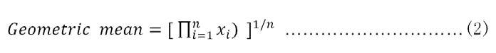

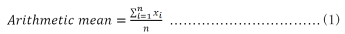

Assume that we have three numbers of a, b, and c. Then their arithmetic mean is (a+b+c)/3, while their geometric mean is (a*b*c)^(1/3). For three values of 2, 3, and 4, we have the following two means:

```python
print("arithmetic mean", (2+3+4)/3.)

geo_mean=(2*3*4)**(1./3)
round(geo_mean,4)
```

```
arithmetic mean 3.0
```

```
2.8845
```

If n returns are given, the formula to estimate their arithmetic mean remains the same. However, the geometric mean formula for returns is different, as shown here:

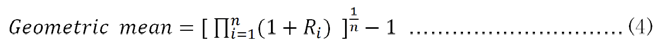

To estimate a geometric mean, the sp.prod() function would be applied. The function gives us the products of all data items; see the following code:

```python
import scipy as sp
import numpy as np

ret=sp.array([0.1,0.05,0.02])
print("arithmetic mean",sp.mean(ret))
print("geo mean", pow(sp.prod(ret+1),1/len(ret))-1)
```

```
arithmetic mean 0.05666666666666667
geo mean 0.05615433350379684
```

Actually, a simple Python function could be written with just two lines to calculate a geometric mean for a set of given returns; see the following code:

```python
def getGeoMeanReturn(x):
    return pow(sp.prod(ret+1),1/len(x))-1
getGeoMeanReturn(ret)
```

```
0.05615433350379684
```

Two other useful functions are sp.unique() and sp.median(), as shown in the following code:

```python
print(sp.unique([2,3,4,6,6,4,4]))

print(sp.median([1,2,3,4,5]))
```

```
[2 3 4 6]
3.0
```

```python
#dir(sp)
#dir(np) to see all the function related to numpy and scipy
```

### Introduction to matplotlib

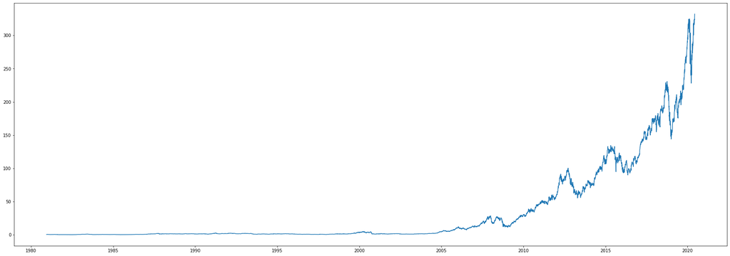

```python
# from pandas_datareader import data
# start, end = '2018-01-11', '2020-01-11'
# aapl = data.DataReader('aapl', start=start,end=end, data_source='yahoo')
# print(aapl)

from yahoo_fin import stock_info as si

# pulls historical OHLC data into a pandas data frame
a=si.get_data("aapl")
a.head()
import matplotlib.pyplot as plt
plt.figure(figsize=(30, 10.5))
plt.plot(a.index,a['open'])
```

```python
from pandas_datareader import data
start, end = '2018-01-11', '2020-01-11'
aapl = data.DataReader('aapl', start=start,end=end, data_source='yahoo')
aapl
```

| Date | High | Low | Open | Close | Volume | Adj Close |
| --- | --- | --- | --- | --- | --- | --- |
| 2018-01-11 | 175.490005 | 174.490005 | 174.589996 | 175.279999 | 18667700.0 | 169.270157 |
| 2018-01-12 | 177.360001 | 175.649994 | 176.179993 | 177.089996 | 25418100.0 | 171.018112 |
| 2018-01-16 | 179.389999 | 176.139999 | 177.899994 | 176.190002 | 29565900.0 | 170.148972 |
| 2018-01-17 | 179.250000 | 175.070007 | 176.149994 | 179.100006 | 34386800.0 | 172.959213 |
| 2018-01-18 | 180.100006 | 178.250000 | 179.369995 | 179.259995 | 31193400.0 | 173.113693 |
| ... | ... | ... | ... | ... | ... | ... |
| 2020-01-06 | 299.959991 | 292.750000 | 293.790009 | 299.799988 | 29596800.0 | 298.282715 |
| 2020-01-07 | 300.899994 | 297.480011 | 299.839996 | 298.390015 | 27218000.0 | 296.879883 |
| 2020-01-08 | 304.440002 | 297.160004 | 297.160004 | 303.190002 | 33019800.0 | 301.655548 |
| 2020-01-09 | 310.429993 | 306.200012 | 307.239990 | 309.630005 | 42527100.0 | 308.062988 |
| 2020-01-10 | 312.670013 | 308.250000 | 310.600006 | 310.329987 | 35161200.0 | 308.759399 |

503 rows × 6 columns

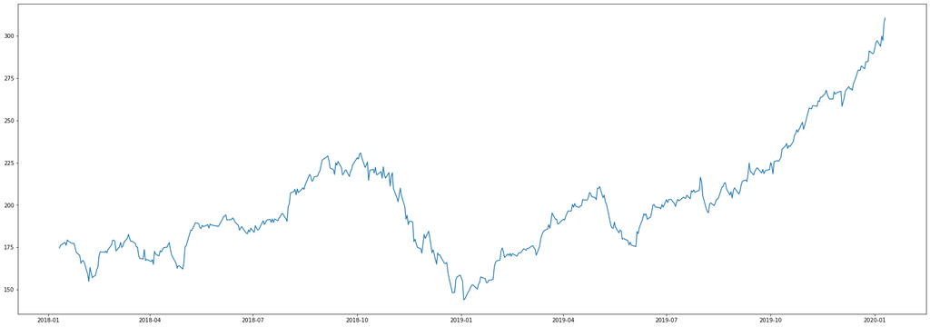

```python
plt.figure(figsize=(30, 10.5))
plt.plot(aapl.index,aapl['Open'])
```

```python
import numpy.lib.financial as fin
dir(fin)
```

[output not shown]